# C7 Week 1

JAGV

2024-05-28

# Regression

Regression models are the workhorse of data science. They are the most well described, practical and theoretically understood models in statistics. A Data Scientist well versed in Regression Models will be able to solve an incredible array of problems.

One key insight for regression models is that they produce highly interpretable model fits. This is unlike the machine learning algorithms,which often sacrifice interpretability for improved prediction performance or automation. These are, of course, valuable attributes in their own rights. However, the benefit of simplicity, parsimony and interpretability offered by regression models (and their close generalizations) should make them a first tool of choice for any practical problem.

## Questions for this class

- To use the parents’ heights to predict childrens’ heights
- To try to find a parsimonious, easily described mean relationship between parent and childrens’ heights.
- To investigate the variation in childrens’ heights that appears unrelated to parents’ heights (residual variation).
- To quantify what impact genotype information has beyond parental height in explaining child height.
- To figure out how/whether and what assumptions are needed to generalize findings beyond the data in question.
- Why do children of very tall parents tend to be tall, but a little shorter than their parents and why children of very short parents tend to be short, but a little bit taller than their parents? (This is a famous question called *Regression to the mean*).

It was [Francis Galton](https://es.wikipedia.org/wiki/Francis_Galton) the one who invented the term and concepts of regression and correlation. His paper is entitled *Regression towars mediocrity in hereditary stature* (published in the Journal of the Anthropological Institute of Great Britain and Ireland, Vol. 15 (1886)). *Fun fact*: he was the cousin of Charles Darwin.

The Galton data is found in the R package `UsingR`

```r
library(UsingR)
data(galton)
library(reshape)
long <- melt(galton)
```

```
## Using  as id variables
```

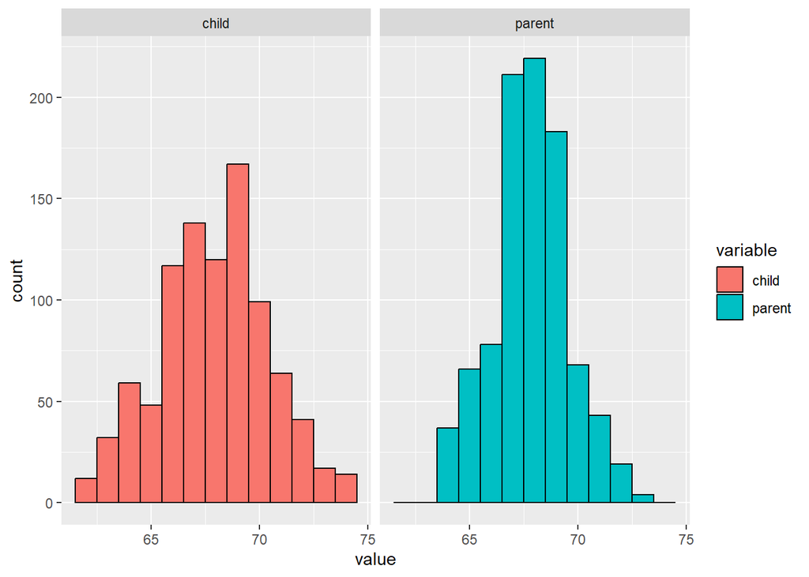

```r
library(ggplot2)
g <- ggplot(long, aes(x = value, fill = variable))
g <- g + geom_histogram(colour = "black", binwidth = 1)
g <- g + facet_grid(.~ variable)
g
```

We can define “the middle” of the distribution as the value of $\mu$ that minimizes